# Case Study One: An Analysis on the Gross Domestic Product and Income of Countries in 2012

Jason Cessna

3/21/2017

## INTRODUCTION

This is a statistical analysis conducted on the Gross Domestic Product of countries in 2012 in direct relation to Education Data we have received which denotes the income level of countries. We will combine these data together to compare the relationship between the ranking of countries in terms of their GDP (gross domestic product) and their income grouping levels. To perform this analysis we will use R. The data files we will be using for analysis can be found here: Gross Domestic Product of 2012: https://d396qusza40orc.cloudfront.net/getdata%2Fdata%2FGDP.csv Eudcational Data: https://d396qusza40orc.cloudfront.net/getdata%2Fdata%2FEDSTATS_Country.csv

We will start our analysis by installing the proper packages into R (ggplot2, dplyr, and doBy). We will need these for our statistical analysis and visualization of our data.

## INSTALL PACKAGES

(the installation is currently commented out of this markdown as the mirrors have not been provided by the developer. find the mirrors for your country to download the packages here: https://cran.r-project.org/mirrors.html)

```r
##source('Analysis/installPackages.R', echo=TRUE)
```

```
##install.packages('ggplot2',repos = "http://cran.us.r-project.org")
##install.packages('doBy',repos = "http://cran.us.r-project.org")
##install.packages('dplyr',repos = "http://cran.us.r-project.org")
```

Then we download the data

## DOWNLOAD DATA

```r
source('Analysis/downloadData.R', echo=TRUE)
```

```
##
## > grossDomProduct <- read.csv("https://d396qusza40orc.cloudfront.net/getdata%2Fdata%2FGDP.csv",
## +     header = FALSE, sep = ",", stringsAsFactors = F .... [TRUNCATED]
##
## > educationData <- read.csv("https://d396qusza40orc.cloudfront.net/getdata%2Fdata%2FEDSTATS_Country.csv",
## +     header = TRUE, sep = ",", stringsAsFa .... [TRUNCATED]
```

Now we need to clean our data to make sure there is no unncessary blank spaces that would interfere with our analysis. We are also preparing to merge the two data files on their short code (or country code) so we have all relevant information for each country provided in both documents.

## CLEAN DATA

```r
source('Analysis/cleanData.R', echo=TRUE)
```

```
##
## > countNA <- function(x) {
## +     count <- vector()
## +     for (name in names(x)) {
## +         count <- append(count, sapply(x[name], function(y) sum(len .... [TRUNCATED]
##
## > countElipse <- function(x) {
## +     count <- vector()
## +     for (name in names(x)) {
## +         count <- append(count, sapply(x[name], function(y) sum .... [TRUNCATED]
##
## > countBlank <- function(x) {
## +     count <- vector()
## +     for (name in names(x)) {
## +         count <- append(count, sapply(x[name], function(y) sum( .... [TRUNCATED]
##
## > checkBadValues <- function(x) {
## +     countNA <- countNA(x)
## +     countBlank <- countBlank(x)
## +     countElipse <- countElipse(x)
## +     return(data. .... [TRUNCATED]
##
## > checkBadValues(grossDomProduct)
##     countNA countBlank countElipse
## V1        0          1           0
## V2        0          1           0
## V3      326          0           0
## V4        0          1           0
## V5        0          1           1
## V6        0          1           0
## V7      326          0           0
## V8      326          0           0
## V9      326          0           0
## V10     326          0           0
##
## > grossDomProduct$V3 <- NULL
##
## > grossDomProduct$V6 <- NULL
##
## > grossDomProduct$V7 <- NULL
```

[output cut: 93 more lines]

```
## > checkBadValues(educationData)
##              countNA countBlank countElipse
## CountryCode        0          0           0
## Long.Name          0          0           0
## Income.Group       0          1           0
## Short.Name         0          0           0
##
## > grossDomProduct <- grossDomProduct[-c(191:330), ]
##
## > checkBadValues(grossDomProduct)
##                      countNA countBlank countElipse
## CountryCode                0          0           0
## Ranking                    0          0           0
## LongName                   0          0           0
## GrossDomesticProduct       0          0           0
```

Now that our data is clean, we need to merge the two data frames together. In order to do so, we must make sure that the numerical data from our gross domestic product data frame is converted properly so the statistical analysis can be executed properly after the merge.

## MERGE DATA

```r
source('Analysis/mergeData.R', echo=TRUE)
```

```
##
## > suppressWarnings(as.numeric(grossDomProduct$Ranking))
##   [1]   1   2   3   4   5   6   7   8   9  10  11  12  13  14  15  16  17
##  [18]  18  19  20  21  22  23  24  25  26  27  28  29  30  31  32  33  34
##  [35]  35  36  37  38  39  40  41  42  43  44  45  46  47  48  49  50  51
##  [52]  52  53  54  55  56  57  58  59  60  61  62  63  64  65  66  67  68
##  [69]  69  70  71  72  73  74  75  76  77  78  79  80  81  82  83  84  85
##  [86]  86  87  88  89  90  91  92  93  94  95  96  97  98  99 100 101 102
## [103] 103 104 105 106 107 108 109 110 111 112 113 114 115 116 117 118 119
## [120] 120 121 122 123 124 125 126 127 128 129 130 131 132 133 134 135 136
## [137] 137 138 139 140 141 142 143 144 145 146 147 148 149 150 151 152 153
## [154] 154 155 156 157 158 159 160 161 162 163 164 165 166 167 168 169 170
## [171] 171 172 173 174 175 176 177 178 178 180 181 182 183 184 185 186 187
## [188] 188 189 190
##
## > grossDomProduct$Ranking <- as.numeric(grossDomProduct$Ranking)
##
## > suppressWarnings(as.numeric(grossDomProduct$GrossDomesticProduct))
##   [1]  NA  NA  NA  NA  NA  NA  NA  NA  NA  NA  NA  NA  NA  NA  NA  NA  NA
##  [18]  NA  NA  NA  NA  NA  NA  NA  NA  NA  NA  NA  NA  NA  NA  NA  NA  NA
##  [35]  NA  NA  NA  NA  NA  NA  NA  NA  NA  NA  NA  NA  NA  NA  NA  NA  NA
##  [52]  NA  NA  NA  NA  NA  NA  NA  NA  NA  NA  NA  NA  NA  NA  NA  NA  NA
##  [69]  NA  NA  NA  NA  NA  NA  NA  NA  NA  NA  NA  NA  NA  NA  NA  NA  NA
##  [86]  NA  NA  NA  NA  NA  NA  NA  NA  NA  NA  NA  NA  NA  NA  NA  NA  NA
## [103]  NA  NA  NA  NA  NA  NA  NA  NA  NA  NA  NA  NA  NA  NA  NA  NA  NA
## [120]  NA  NA  NA  NA  NA  NA  NA  NA  NA  NA  NA  NA  NA  NA  NA  NA  NA
## [137]  NA  NA  NA  NA  NA  NA  NA  NA  NA  NA  NA  NA  NA  NA  NA  NA  NA
## [154]  NA  NA  NA  NA  NA  NA  NA  NA  NA  NA  NA  NA  NA  NA  NA  NA  NA
## [171]  NA  NA  NA  NA 917 822 787 767 767 713 684 596 480 472 326 263 228
## [188] 182 175  40
##
## > head(grossDomProduct$GrossDomesticProduct)
## [1] " 16,244,600 " " 8,227,103 "  " 5,959,718 "  " 3,428,131 "
## [5] " 2,612,878 "  " 2,471,784 "
##
## > suppressWarnings(as.numeric(",", "", grossDomProduct$GrossDomesticProduct))
## [1] NA
##
## > grossDomProduct$GrossDomesticProduct <- gsub(",",
## +     "", grossDomProduct$GrossDomesticProduct)
```

[output cut: 82 more lines]

```
##  $ LongName            : chr  "Aruba" "Afghanistan" "Angola" "Albania" ...
##  $ GrossDomesticProduct: num  2584 20497 114147 12648 348595 ...
##  $ Long.Name           : Factor w/ 234 levels "American Samoa",..: 5 57 99 109 226 4 110 2 15 111 ...
##  $ Income.Group        : Factor w/ 6 levels "","High income: nonOECD",..: 2 4 5 6 2 6 5 6 3 3 ...
##  $ Short.Name          : Factor w/ 234 levels "Afghanistan",..: 10 1 6 2 220 8 9 7 11 12 ...
##
## > checkBadValues(productAndEducation)
##                      countNA countBlank countElipse
## CountryCode                0          0           0
## Ranking                    0          0           0
## LongName                   0          0           0
## GrossDomesticProduct       0          0           0
## Long.Name                  0          0           0
## Income.Group               0          0           0
## Short.Name                 0          0           0
```

Now that our data is merged, we can perform statistical analysis on it. The questions we are looking to answer are as follows:

## QUESTION 1

Merge the data based on the country shortcode. How many of the IDs match? Since we already merged the data based on the country shortcode, we are just looking to discover how many matches we had in total (ie: how many countries have valid data for our analysis?)

```r
source('Analysis/question1.R', echo=TRUE)
```

```
##
## > length(grossDomProduct$CountryCode)
## [1] 190
##
## > length(educationData$CountryCode)
## [1] 234
##
## > length((productAndEducation$CountryCode))
## [1] 189
```

Out of the 190 country codes in our Gross Domestic Product data and the 234 country codes in the Educational Data, we are able to match and merge on 189 total country codes.

## QUESTION 2

Sort the data frame in ascending order by GDP (so United States is last). What is the 13th country in the resulting data frame?

```r
source('Analysis/question2.R', echo=TRUE)
```

```
##
## > productAndEducation <- productAndEducation[order(productAndEducation$GrossDomesticProduct),
## +     ]
##
## > productAndEducation$GrossDomesticProduct
##   [1]       40      175      182      228      263      326      472
##   [8]      480      596      684      713      767      767      787
##  [15]      822      917     1008     1129     1134     1239     1293
##  [22]     1493     1734     1780     1827     2184     2222     2448
##  [29]     2472     2584     2851     3092     3744     3796     3814
##  [36]     3908     4199     4225     4264     4373     5012     5474
##  [43]     5632     6075     6445     6475     6773     6972     7103
##  [50]     7253     7557     7843     8149     8722     9418     9613
##  [57]     9802     9951     9975    10271    10308    10441    10486
##  [64]    10507    12648    12887    13072    13579    13678    14038
```

[output cut: 20 more lines]

The country with the 13th-lowest generated domestic product is St. Kitts and Nevis

## QUESTION 3

What are the average GDP rankings for the “High income: OECD” and “High income: nonOECD” groups?

```r
source('Analysis/question3.R', echo=TRUE)
```

```
##
## > mean(productAndEducation$Ranking[productAndEducation$Income.Group ==
## +     "High income: OECD"])
## [1] 32.96667
##
## > mean(productAndEducation$Ranking[productAndEducation$Income.Group ==
## +     "High income: nonOECD"])
## [1] 91.91304
```

The average (or mean) of the ranking of countries based on their GDP in the High Income: OECD income group is 32.97, and the mean of the rankings of countries based on their GDP in the High Income: nonOECD income group is 91.91.

## QUESTION 4

Show the distribution of GDP value for all the countries and color plots by income group. Use ggplot2 to create your plot.

```r
source('Analysis/question4.R', echo=TRUE)
```

```
##
## > library(ggplot2)
##
## > library(scales)
##
## > allIncomeGroups <- unique(productAndEducation[c("Income.Group")])
##
## > allIncomeGroups
##             Income.Group
## 173  Lower middle income
## 137  Upper middle income
## 39            Low income
## 1   High income: nonOECD
## 82     High income: OECD
##
## > gdpPlot <- ggplot(data = productAndEducation, aes(reorder(CountryCode,
## +     GrossDomesticProduct), y = GrossDomesticProduct))
##
## > gdpPlot + geom_point(aes(color = Income.Group)) +
## +     labs(title = "Gross Domestic Product by Country", y = "2012 Gross Domestic Product (by Mill ..." ... [TRUNCATED]
```

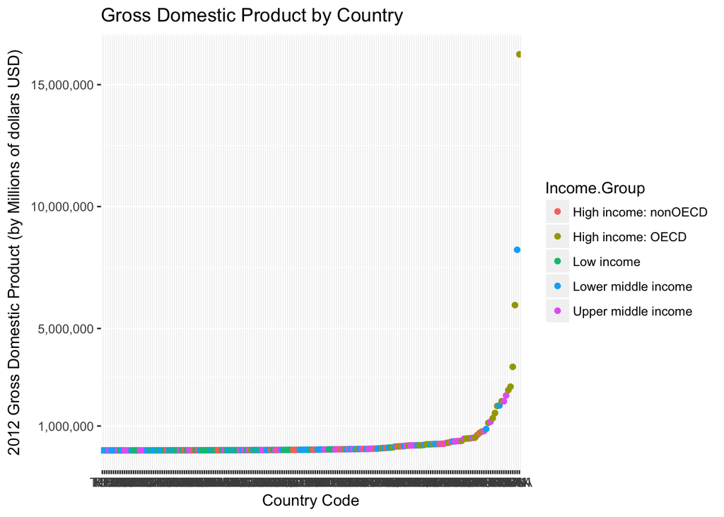

## QUESTION 5

Provide summary statistics of GDP by income groups.

```r
source('Analysis/question5.R', echo=TRUE)
```

```
##
## > library(dplyr)
```

```
##
## > library(doBy)
##
## > tapply(productAndEducation$GrossDomesticProduct, productAndEducation$Income.Group,
## +     summary)
## [[1]]
## NULL
##
## $`High income: nonOECD`
##    Min. 1st Qu.  Median    Mean 3rd Qu.    Max.
##    2584   12840   28370  104300  131200  711000
##
## $`High income: OECD`
##     Min.  1st Qu.   Median     Mean  3rd Qu.     Max.
##    13580   211100   486500  1484000  1480000 16240000
##
## $`Low income`
##    Min. 1st Qu.  Median    Mean 3rd Qu.    Max.
##     596    3814    7843   14410   17200  116400
##
## $`Lower middle income`
##    Min. 1st Qu.  Median    Mean 3rd Qu.    Max.
##      40    2549   24270  256700   81450 8227000
##
## $`Upper middle income`
##    Min. 1st Qu.  Median    Mean 3rd Qu.    Max.
##     228    9613   42940  231800  205800 2253000
##
##
## > summaryBy(GrossDomesticProduct ~ Income.Group, data = productAndEducation,
## +     FUN = function(x) {
## +         c(mean = mean(x), stdev = sd(x), sum .... [TRUNCATED]
##           Income.Group GrossDomesticProduct.mean
## 1 High income: nonOECD                 104349.83
## 2    High income: OECD                1483917.13
## 3           Low income                  14410.78
## 4  Lower middle income                 256663.48
## 5  Upper middle income                 231847.84
##   GrossDomesticProduct.stdev GrossDomesticProduct.sum
## 1                  165334.45                  2400046
## 2                 3070463.52                 44517514
## 3                   20473.09                   533199
## 4                 1139619.92                 13859828
## 5                  476872.04                 10433153
##   GrossDomesticProduct.count
## 1                         23
## 2                         30
## 3                         37
## 4                         54
## 5                         45
```

Below we have the summary statistics for each income group based on their GDP:

```
IncomeGroup             Min.    1st Qu.   Median    Mean      3rd Qu.    Max
High income: nonOECD    2584    12840     28370     104300    131200     711000
High income: OECD       13580   211100    486500    1484000   1480000    16240000
Low income              596     3814      7843      14410     17200      116400
Lower middle income     40      2549      24270     256700    81450      8227000
Upper middle income     228     9613      42940     231800    205800     2253000
```

Below we have some additonal statistical data from each income group based on its GDP:

```
INCOME GROUP             MEAN      standard deviation(GDP)    sum of GDP     count of countries
High income: nonOECD     104349.83        165334.45           2400046        23
High income: OECD        1483917.13       3070463.52          44517514       30
Low income               14410.78         20473.09            533199         37
Lower middle income      256663.48        1139619.92          13859828       54
Upper middle income      231847.84        476872.04           10433153       45
```

## QUESTION 6

Cut the GDP ranking into 5 separate quantile groups. Make a table versus Income.Group. How many countries are Lower middle income but among the 38 nations with highest GDP?

```r
source('Analysis/question6.R', echo=TRUE)
```

```
##
## > GDPE <- data.frame(ntile(productAndEducation$GrossDomesticProduct,
## +     n = 5), productAndEducation$GrossDomesticProduct, productAndEducation$Inco .... [TRUNCATED]
##
## > names(GDPE) <- c("Quantile", "GrossDomesticProduct",
## +     "IncomeGroup")
##
## > xtabs(~GDPE$Quantile + GDPE$IncomeGroup)
##              GDPE$IncomeGroup
## GDPE$Quantile    High income: nonOECD High income: OECD Low income
##             1  0                    2                 0         11
##             2  0                    4                 1         16
##             3  0                    8                 1          9
##             4  0                    5                10          1
##             5  0                    4                18          0
##              GDPE$IncomeGroup
## GDPE$Quantile Lower middle income Upper middle income
##             1                  16                   9
##             2                   9                   8
##             3                  11                   9
##             4                  14                   8
##             5                   4                  11
```

The table can be seen below:

```
Quantile | High income: nonOECD | High income: OECD | Low income |Lower middle income | Upper middle income
1                    2                    0                11               16                  9
2                    4                    1                16                9                  8
3                    8                    1                 9               11                  9
4                    5                   10                 1               14                  8
5                    4                   18                 0                4                 11
```

## CONCLUSION

The analysis we have conducted on these data has showed us a qualitative comparison between countries based on their income groups, rankings, and gross domestic product. We did not find that there is a constant correlation between a high GDP and high income within countries and raises more questions that we can perform additional analysis on if we can obtain more data (ie: products produced, services sold, mean wages for citizens in those jobs, and mean populations for each country) like the correlation between population’s wages of a certain industry and the overall profits which the country receives on them.

We also see (in our plot) that only 3 countries have a GDP over 5 trillion in 2012, one of which had an income that places that country in the lower-middle income group. Less than 25% of countries had a GDP of above 1 trillion USD in 2012, and their incomes vary tremendously as well.

With both of these observations, we can conclude that there is not a direct correlation between the gross domestic product of a country and their overall income.